# Assignment 1

Sam Raby

September 13, 2016

Load in Data:

```r
source("http://www.openintro.org/stat/data/arbuthnot.R")

source("http://www.openintro.org/stat/data/present.R")
```

# 1. What years are included in this data set? What are the dimensions of the data frame and what are the variable or column names?

```r
present
```

```
##    year    boys   girls
## 1  1940 1211684 1148715
## 2  1941 1289734 1223693
## 3  1942 1444365 1364631
## 4  1943 1508959 1427901
## 5  1944 1435301 1359499
## 6  1945 1404587 1330869
## 7  1946 1691220 1597452
## 8  1947 1899876 1800064
## 9  1948 1813852 1721216
## 10 1949 1826352 1733177
## 11 1950 1823555 1730594
## 12 1951 1923020 1827830
## 13 1952 1971262 1875724
## 14 1953 2001798 1900322
```

[output cut: 49 more lines]

```r
dim(present)
```

```
## [1] 63  3
```

```r
names(present)
```

```
## [1] "year"  "boys"  "girls"
```

Solution: The “present” dataset includes years 1940-2002. The dimensions of the data frame are 63 observations with 3 variables each. The column names are “year”, “boys”, and “girls”.

# 2. How do the counts of boys and girls in the present day birth records compare to Arbuthnot’s? Are they on a similar scale?

```r
arbuthnot
```

```
##    year boys girls
## 1  1629 5218  4683
## 2  1630 4858  4457
## 3  1631 4422  4102
## 4  1632 4994  4590
## 5  1633 5158  4839
## 6  1634 5035  4820
## 7  1635 5106  4928
## 8  1636 4917  4605
## 9  1637 4703  4457
## 10 1638 5359  4952
## 11 1639 5366  4784
## 12 1640 5518  5332
## 13 1641 5470  5200
## 14 1642 5460  4910
```

[output cut: 68 more lines]

Solution: The counts of boys/girls in the arbuthnot dataset seem to be in the range of about 2,500-8,500 per gender per year. The counts for boys/girls in the present dataset seem to be in a range of about 1,200,000 - 2,200,000 per gender per year. Therefore, these datasets are on very different scales!

# 3. Make a plot that displays the boy-to-girl ratio for every year in the data set. What do you see? Does Arbuthnot’s observation about boys being born in greater proportion than girls hold up in the U.S.? Include the plot in your response.

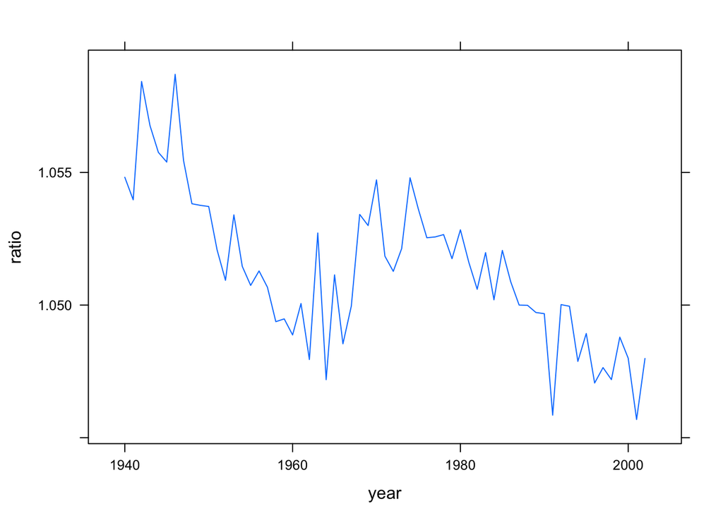

```r
require(mosaic)
present$ratio<-present$boys / present$girls
xyplot(ratio ~ year, data=present, type="l")
```

Solution: The accompanying plot shows that the ratio between boys and girls stays within the range 1.045 to 1.060 boys for every girl. This is consistent with Arbuthnot’s observation about buys being born in greeter proportion than girls. However, this is perhaps a more compelling dataset since the scale of this US dataset is so much larger than Arbuthnot’s.

# 4. In what year did we see the most total number of births in the US?

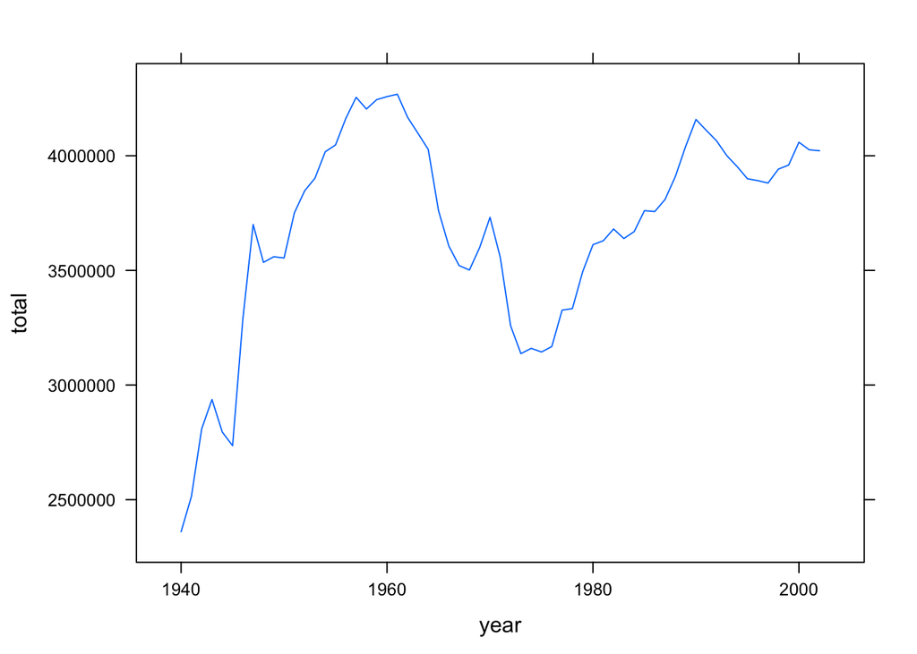

```r
present$total<-present$boys + present$girls

xyplot(total ~ year, data=present, type="l")
```

By generating a new column of total births, generating an xy-plot, and sorting the present dataset table to see its maximum value, we can see that the most total number of births in the U.S. occurred in 1961 with a total of 4,268,326 births.